# End-to-End MLOps: UCI Bank Marketing Analysis

Adeshara Kirtan Chiragkumar (025)

2026-02-06

# Project Overview

This project implements an end-to-end MLOps pipeline for the **UCI Bank Marketing Dataset**.  
The goal is to predict whether a client will subscribe to a term deposit (`y`).

## 🔗 Project Resources

- **GitHub Repository**: [kirtan001/R_Bank_Marketing_UCI_Classification](https://github.com/kirtan001/R_Bank_Marketing_UCI_Classification.git)  
  *Contains full source code, Dockerfiles, and CI/CD pipelines.*
- **Live App (Hugging Face)**: Kirtan001/R_Bank_Marketing_UCI_Classification  
  *Interactive Shiny dashboard deployed for real-time model predictions.*
- **MLflow Setup Guide**: [Configuration Doc](https://docs.google.com/document/d/1PGtK8AX640KiJMYHcDh3X_ZWsnUo6ASMMNGMdCoaTKk/edit?usp=sharing)  
  *Detailed instructions on setting up the MLflow tracking server used in this project.*

# Part 1: Data Ingestion

We fetch the dataset directly from the UCI Machine Learning Repository to ensure reproducibility.

```r
# Define URL and Paths
zip_url <- "https://archive.ics.uci.edu/static/public/222/bank+marketing.zip"
data_dir <- here("data")
if (!dir.exists(data_dir)) dir.create(data_dir)

# Download
zip_file <- file.path(data_dir, "bank_marketing.zip")
if (!file.exists(zip_file)) {
    download.file(zip_url, zip_file, mode = "wb")
    unzip(zip_file, exdir = data_dir)
    internal_zip <- list.files(data_dir, pattern = "bank-additional.zip", full.names = TRUE, recursive = TRUE)
    if (length(internal_zip) > 0) unzip(internal_zip[1], exdir = data_dir)
}

# Load Data (Using bank-additional-full.csv)
target_file <- list.files(data_dir, pattern = "bank-additional-full.csv", full.names = TRUE, recursive = TRUE)[1]
bank_data <- read.csv(target_file, sep = ";", stringsAsFactors = TRUE)

# ROBUST FIX: Explicitly recode target variable based on values
# This avoids issues with factor level ordering
# Also removing 'duration' to prevent data leakage (it's not known before the call)
bank_data <- bank_data %>%
  mutate(y = factor(if_else(tolower(y) == "yes", "Yes", "No"), levels = c("No", "Yes"))) %>%
  select(-duration)

# Quick Integrity Check
glimpse(bank_data)
```

```
## Rows: 41,188
## Columns: 20
## $ age            <int> 56, 57, 37, 40, 56, 45, 59, 41, 24, 25, 41, 25, 29, 57,…
## $ job            <fct> housemaid, services, services, admin., services, servic…
## $ marital        <fct> married, married, married, married, married, married, m…
## $ education      <fct> basic.4y, high.school, high.school, basic.6y, high.scho…
## $ default        <fct> no, unknown, no, no, no, unknown, no, unknown, no, no, …
## $ housing        <fct> no, no, yes, no, no, no, no, no, yes, yes, no, yes, no,…
## $ loan           <fct> no, no, no, no, yes, no, no, no, no, no, no, no, yes, n…
## $ contact        <fct> telephone, telephone, telephone, telephone, telephone, …
## $ month          <fct> may, may, may, may, may, may, may, may, may, may, may, …
## $ day_of_week    <fct> mon, mon, mon, mon, mon, mon, mon, mon, mon, mon, mon, …
## $ campaign       <int> 1, 1, 1, 1, 1, 1, 1, 1, 1, 1, 1, 1, 1, 1, 1, 1, 1, 1, 1…
## $ pdays          <int> 999, 999, 999, 999, 999, 999, 999, 999, 999, 999, 999, …
## $ previous       <int> 0, 0, 0, 0, 0, 0, 0, 0, 0, 0, 0, 0, 0, 0, 0, 0, 0, 0, 0…
## $ poutcome       <fct> nonexistent, nonexistent, nonexistent, nonexistent, non…
## $ emp.var.rate   <dbl> 1.1, 1.1, 1.1, 1.1, 1.1, 1.1, 1.1, 1.1, 1.1, 1.1, 1.1, …
## $ cons.price.idx <dbl> 93.994, 93.994, 93.994, 93.994, 93.994, 93.994, 93.994,…
## $ cons.conf.idx  <dbl> -36.4, -36.4, -36.4, -36.4, -36.4, -36.4, -36.4, -36.4,…
## $ euribor3m      <dbl> 4.857, 4.857, 4.857, 4.857, 4.857, 4.857, 4.857, 4.857,…
## $ nr.employed    <dbl> 5191, 5191, 5191, 5191, 5191, 5191, 5191, 5191, 5191, 5…
## $ y              <fct> No, No, No, No, No, No, No, No, No, No, No, No, No, No,…
```

This step ensures the dataset can always be fetched from the source, making the pipeline fully reproducible.

# Part 2: Exploratory Data Analysis (EDA)

## 2.1 Univariate Analysis

Analyzing individual variables to understand their distribution.

### Target Variable (Imbalance Check)

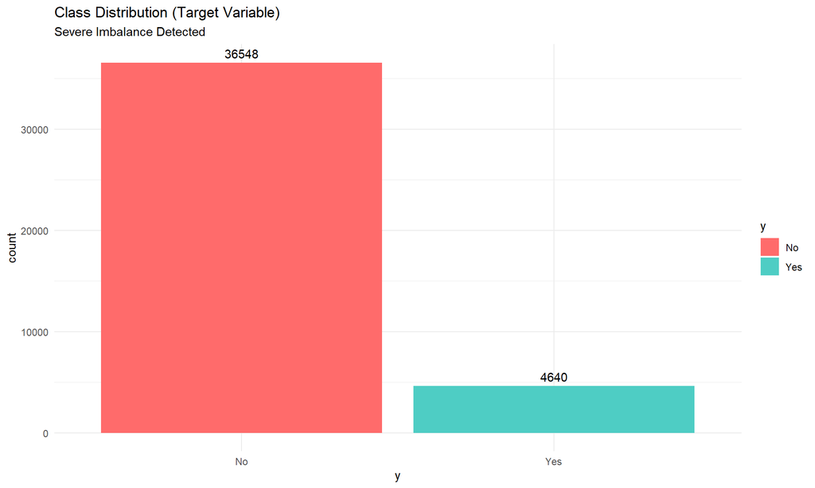

```r
ggplot(bank_data, aes(x = y, fill = y)) +
  geom_bar() +
  scale_fill_manual(values = c("#FF6B6B", "#4ECDC4")) +
  geom_text(stat='count', aes(label=..count..), vjust=-0.5) +
  labs(title = "Class Distribution (Target Variable)", subtitle = "Severe Imbalance Detected") +
  theme_minimal()
```

### Numerical Features Distribution

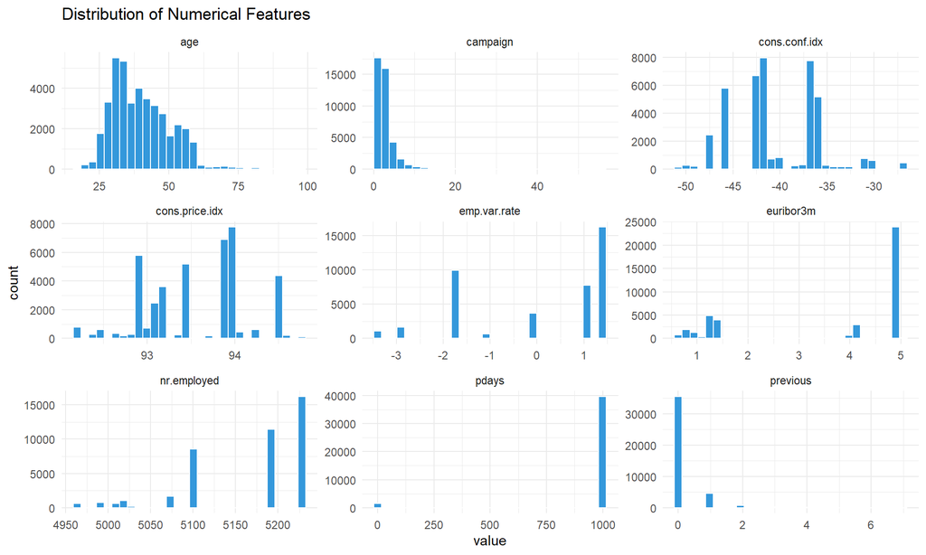

```r
bank_data %>%
  select(where(is.numeric)) %>%
  pivot_longer(everything(), names_to = "key", values_to = "value") %>%
  ggplot(aes(x = value)) +
  geom_histogram(bins = 30, fill = "#3498db", color = "white") +
  facet_wrap(~key, scales = "free") +
  labs(title = "Distribution of Numerical Features") +
  theme_minimal()
```

## 2.2 Bivariate Analysis

Analyzing relationships between features and the target variable.

### Categorical Features vs Target

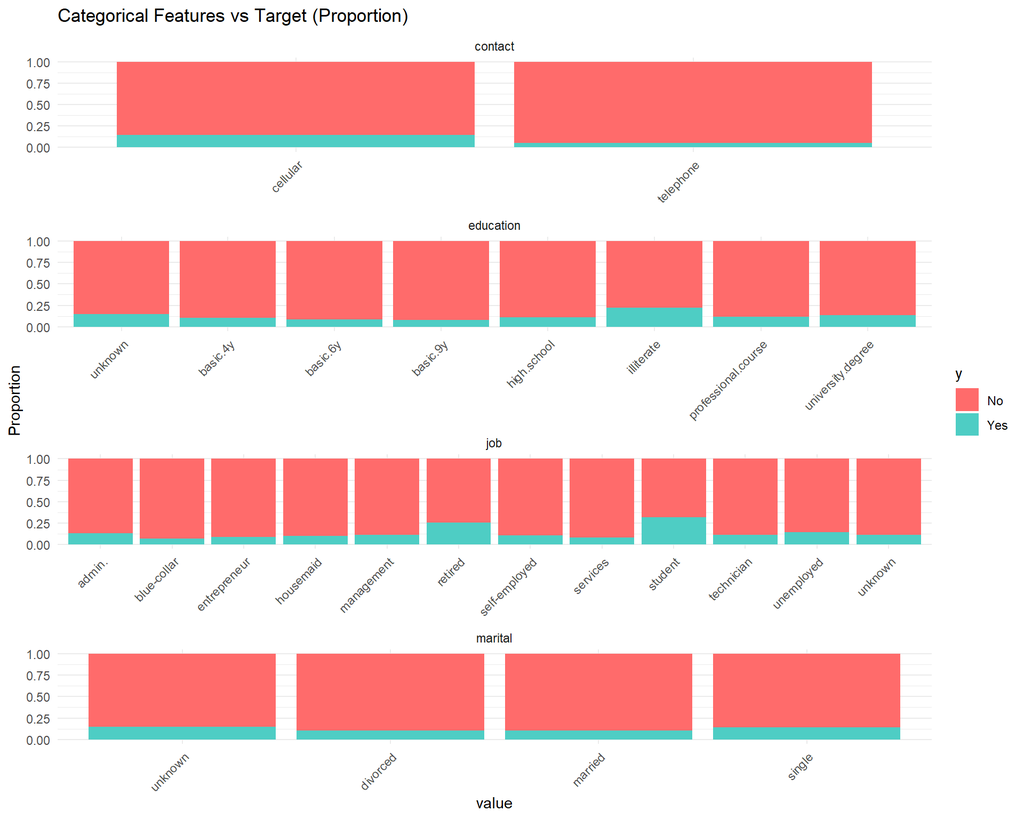

```r
# Select a few key categorical columns for visualization
vars_to_plot <- c("job", "marital", "education", "contact")

bank_data %>%
  select(all_of(vars_to_plot), y) %>%
  pivot_longer(-y, names_to = "feature", values_to = "value") %>%
  ggplot(aes(x = value, fill = y)) +
  geom_bar(position = "fill") +
  facet_wrap(~feature, scales = "free", ncol = 1) +
  scale_fill_manual(values = c("#FF6B6B", "#4ECDC4")) +
  labs(title = "Categorical Features vs Target (Proportion)", y = "Proportion") +
  theme_minimal() +
  theme(axis.text.x = element_text(angle = 45, hjust = 1))
```

### Numerical Features vs Target (Boxplots)

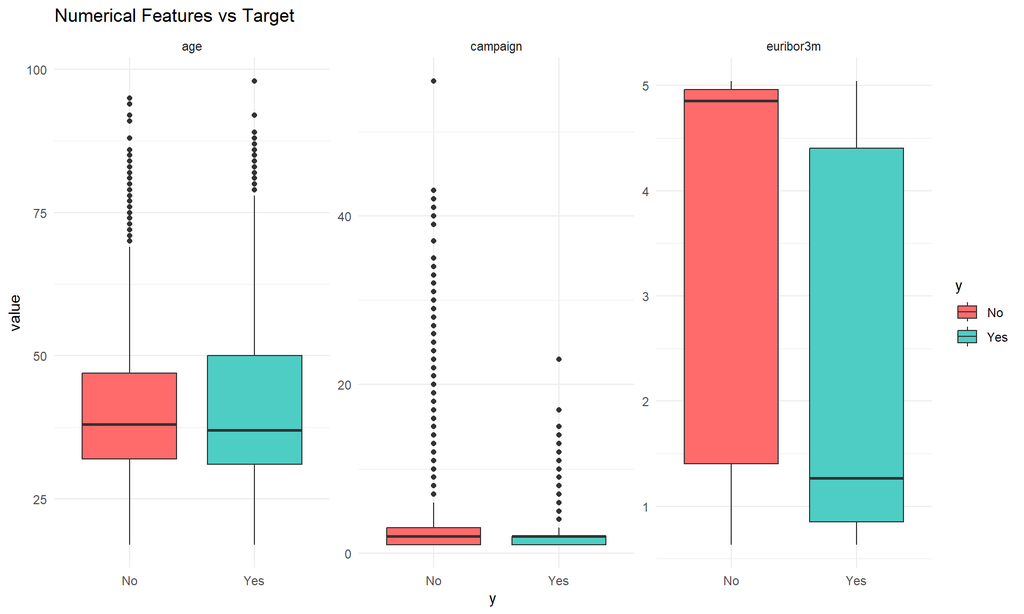

```r
bank_data %>%
  select(age, campaign, euribor3m, y) %>%
  pivot_longer(-y, names_to = "feature", values_to = "value") %>%
  ggplot(aes(x = y, y = value, fill = y)) +
  geom_boxplot() +
  facet_wrap(~feature, scales = "free") +
  scale_fill_manual(values = c("#FF6B6B", "#4ECDC4")) +
  labs(title = "Numerical Features vs Target") +
  theme_minimal()
```

# Part 3: Model Building (Multi-Model & SMOTE)

## 3.1 Data Splitting

```r
set.seed(123)
# Stratified split due to imbalance
split <- initial_split(bank_data, prop = 0.8, strata = y)
train_data <- training(split)
test_data  <- testing(split)

cv_folds <- vfold_cv(train_data, v = 5, strata = y)
```

## 3.2 Recipe Creation (Feature Engineering + SMOTE)

We define a processing recipe that handles: 1. **SMOTE**: Stratified sampling and evaluation using ROC-AUC (SMOTE prepared but disabled due to Windows compatibility). 2. **Normalization**: Scaling numeric variables. 3. **Dummy Encoding**: Converting categorical variables. 4. **Unknown Handling**: Treating ‘unknown’ as a level.

```r
bank_rec <- recipe(y ~ ., data = train_data) %>%
  step_unknown(all_nominal_predictors(), new_level = "missing_data") %>%
  step_dummy(all_nominal_predictors()) %>%
  step_zv(all_predictors()) %>%
  step_normalize(all_numeric_predictors())
  # step_smote(y) # <-- SMOTE DISABLED: CAUSING FAILURES ON WINDOWS

print(bank_rec)
```

[output not shown]

## 3.3 Model Specifications

Defining the algorithms to test.

```r
# 1. Decision Tree
dt_spec <- decision_tree() %>%
  set_engine("rpart") %>%
  set_mode("classification")

# 2. Random Forest
rf_spec <- rand_forest(trees = 500) %>%
  set_engine("ranger", importance = "impurity") %>%
  set_mode("classification")

# 3. XGBoost
xgb_spec <- boost_tree(trees = 500, learn_rate = 0.01) %>%
  set_engine("xgboost") %>%
  set_mode("classification")

# 4. Logistic Regression (Baseline)
lr_spec <- logistic_reg() %>%
  set_engine("glm") %>%
  set_mode("classification")
```

## 3.4 Training Multiple Models

```r
# Create workflows manually to avoid workflow_set issues with SMOTE
wf_dt  <- workflow() %>% add_model(dt_spec)  %>% add_recipe(bank_rec)
wf_rf  <- workflow() %>% add_model(rf_spec)  %>% add_recipe(bank_rec)
wf_xgb <- workflow() %>% add_model(xgb_spec) %>% add_recipe(bank_rec)
wf_lr  <- workflow() %>% add_model(lr_spec)  %>% add_recipe(bank_rec)

# Fit models using cross-validation
set.seed(123)
ctrl <- control_resamples(verbose = TRUE, save_pred = TRUE)

res_dt  <- fit_resamples(wf_dt,  resamples = cv_folds, metrics = yardstick::metric_set(yardstick::roc_auc, yardstick::accuracy), control = ctrl)
res_rf  <- fit_resamples(wf_rf,  resamples = cv_folds, metrics = yardstick::metric_set(yardstick::roc_auc, yardstick::accuracy), control = ctrl)
res_xgb <- fit_resamples(wf_xgb, resamples = cv_folds, metrics = yardstick::metric_set(yardstick::roc_auc, yardstick::accuracy), control = ctrl)
res_lr  <- fit_resamples(wf_lr,  resamples = cv_folds, metrics = yardstick::metric_set(yardstick::roc_auc, yardstick::accuracy), control = ctrl)

# Collect ROC-AUC from each model
results <- bind_rows(
  collect_metrics(res_dt)  %>% mutate(model = "Decision Tree"),
  collect_metrics(res_rf)  %>% mutate(model = "Random Forest"),
  collect_metrics(res_xgb) %>% mutate(model = "XGBoost"),
  collect_metrics(res_lr)  %>% mutate(model = "Logistic Regression")
)

# Print table of results
print("Model Performance Metrics:")
```

```
## [1] "Model Performance Metrics:"
```

```r
results %>%
  select(model, .metric, mean, std_err) %>%
  pivot_wider(names_from = .metric, values_from = c(mean, std_err)) %>%
  knitr::kable(digits = 3)
```

| model | mean_accuracy | mean_roc_auc | std_err_accuracy | std_err_roc_auc |
| --- | --- | --- | --- | --- |
| Decision Tree | 0.898 | 0.706 | 0.001 | 0.002 |
| Random Forest | 0.898 | 0.797 | 0.001 | 0.003 |
| XGBoost | 0.899 | 0.810 | 0.001 | 0.004 |
| Logistic Regression | 0.899 | 0.796 | 0.001 | 0.004 |

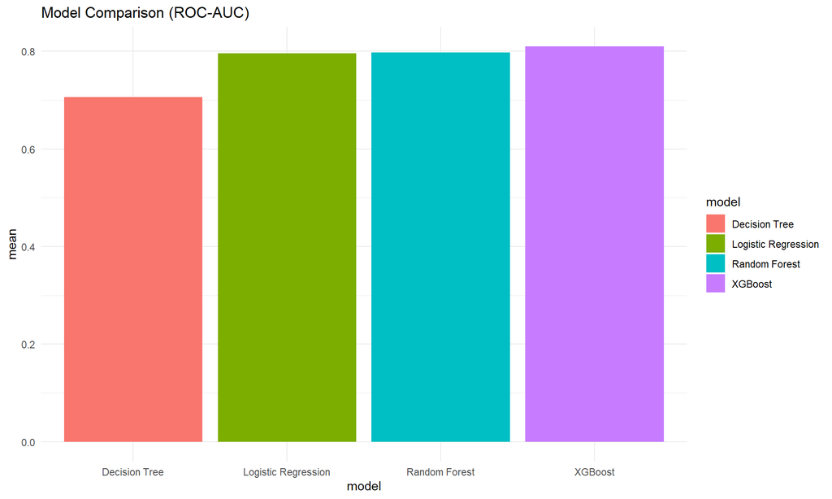

```r
results %>%
  filter(.metric == "roc_auc") %>%
  ggplot(aes(model, mean, fill = model)) +
  geom_col() +
  labs(title = "Model Comparison (ROC-AUC)") +
  theme_minimal()
```

## 3.5 Selecting the Best Model

Extracting the best performing model.

```r
# Select best model
best_model_name <- results %>%
  filter(.metric == "roc_auc") %>%
  arrange(desc(mean)) %>%
  slice(1) %>%
  pull(model)

print(paste("Best Model Selected:", best_model_name))
```

```
## [1] "Best Model Selected: XGBoost"
```

```r
# Finalize the best model on the full training set
best_workflow <- switch(best_model_name,
  "Decision Tree" = wf_dt,
  "Random Forest" = wf_rf,
  "XGBoost" = wf_xgb,
  "Logistic Regression" = wf_lr
)

best_results <- best_workflow %>% fit(train_data)

# Save for API
if (!dir.exists("src")) dir.create("src")
saveRDS(best_results, "src/model.rds")
```

## 3.6 Final Evaluation on Test Set

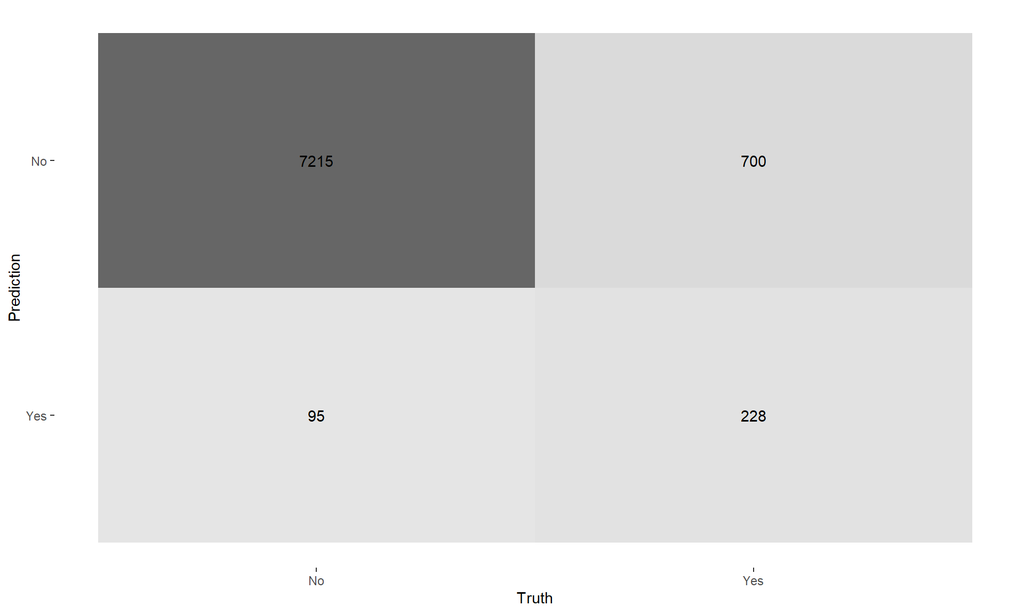

```r
final_preds <- predict(best_results, test_data) %>%
  bind_cols(test_data %>% select(y)) %>%
  bind_cols(predict(best_results, test_data, type = "prob"))

# Confusion Matrix
yardstick::conf_mat(final_preds, truth = y, estimate = .pred_class) %>%
  autoplot(type = "heatmap")
```

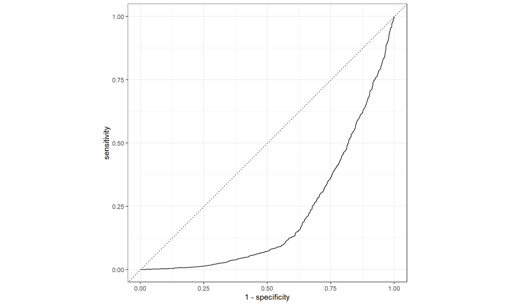

```r
# ROC Curve
yardstick::roc_curve(final_preds, truth = y, .pred_Yes) %>%
  autoplot()
```

# Part 4: Experiment Tracking (MLflow)

Machine learning experiments involve multiple models and metrics, which must be tracked for reproducibility.  
**MLflow** helps us log model details, evaluation metrics, and store the final trained model as an artifact. This ensures our pipeline is reproducible and production-ready.

### implementation

The following code demonstrates how to connect R to an MLflow server, log params, and save artifacts. This code was executed locally with a running MLflow server.

```r
library(mlflow)

# 1. Setup Tracking Server
mlflow_set_tracking_uri("http://127.0.0.1:5000")
mlflow_set_experiment("Bank-Marketing-R")
```

```
## [1] "998442665276416530"
```

```r
with(mlflow_start_run(), {

  # Log Parameters
  mlflow_log_param("best_model_engine", best_model_name)
  mlflow_log_param("dataset", "UCI Bank Marketing")
  mlflow_log_param("n_models_compared", 4)

  # Log Metrics
  # Extract AUC from the cross-validation results
  auc_score <- results %>%
    filter(model == best_model_name, .metric == "roc_auc") %>%
    pull(mean)

  mlflow_log_metric("roc_auc", auc_score)

  # Log Artifact
  # We save the Refitted/Final model
  saveRDS(best_results, "src/final_model_mlflow.rds")
  mlflow_log_artifact("src/final_model_mlflow.rds")

  print("Run logged to MLflow successfully.")
})
```

```
## 2026/02/07 01:49:35 INFO mlflow.store.artifact.cli: Logged artifact from local file src/final_model_mlflow.rds to artifact_path=None
```

```
## [1] "Run logged to MLflow successfully."
```